# Extracting Line random effects and estimates from linear mixed models

Envel Kerdaffrec

6/21/2022

As suggested by Thomas and Rudolf we can extract the Line estimates and their SE using the *mixedup* package. This package can retrieve either random effects (deviations from the intercept) or random coefficients (fixed effects + random effects — similar to the Pop estimates that we have used so far). However, random coefficients can only be extracted from linear models that have been generated using *lme4::lmer* — we have used *afex::lmer* since it computes a *p* value. Below we try to see if random effects only would be sufficient for what we want to do.

We load the DrosEU data and run a simplified model with Line as random factor using wing area data from Banu’s lab.

```r
##### load data
droseu <- readRDS("Data/droseu_master_list_2022-05-02.rds")
```

```r
##### run lme4 model for left wings
wl_lme4 <- lme4::lmer(CentroidSizeLeft_micrometers ~ Population + (1|Line), data = filter(droseu$wa, Supervisor.PI == "Onder"))

##### extract random effects and coefficients
wl_re <- extract_random_effects(wl_lme4, re = "Line")
wl_coef <- extract_random_coefs(wl_lme4, re = "Line")
```

lme4::lmer results

```
## Linear mixed model fit by REML ['lmerMod']
## Formula: CentroidSizeLeft_micrometers ~ Population + (1 | Line)
##    Data: filter(droseu$wa, Supervisor.PI == "Onder")
## REML criterion at convergence: 142044.4
## Random effects:
##  Groups   Name        Std.Dev.
##  Line     (Intercept)  45.64
##  Residual             211.14
## Number of obs: 10477, groups:  Line, 167
## Fixed Effects:
##  (Intercept)  PopulationGI  PopulationKA  PopulationMA  PopulationMU
##     2641.879        31.815        33.228        75.693        37.614
## PopulationRE  PopulationUM  PopulationVA  PopulationYE
##      119.512        75.204        33.043        -2.331
```

Random effects

```
## # A tibble: 6 × 7
##   group_var effect    group   value    se lower_2.5 upper_97.5
##   <chr>     <chr>     <fct>   <dbl> <dbl>     <dbl>      <dbl>
## 1 Line      Intercept AK1     0.747  23.4    -45.1        46.6
## 2 Line      Intercept AK10  -64.6    23.0   -110.        -19.6
## 3 Line      Intercept AK11  -17.4    23.4    -63.3        28.4
## 4 Line      Intercept AK12   40.3    23.4     -5.52       86.2
## 5 Line      Intercept AK13   77.4    23.4     31.6       123.
## 6 Line      Intercept AK14   40.2    23.4     -5.66       86.1
```

Random coefficients

```
## # A tibble: 6 × 7
##   group_var effect    group value    se lower_2.5 upper_97.5
##   <chr>     <chr>     <fct> <dbl> <dbl>     <dbl>      <dbl>
## 1 Line      Intercept AK1   2643.  26.2     2591.      2694.
## 2 Line      Intercept AK10  2577.  25.9     2527.      2628.
## 3 Line      Intercept AK11  2624.  26.2     2573.      2676.
## 4 Line      Intercept AK12  2682.  26.2     2631.      2734.
## 5 Line      Intercept AK13  2719.  26.2     2668.      2771.
## 6 Line      Intercept AK14  2682.  26.2     2631.      2734.
```

By summing the intercept from the model (here = 2641.879) and the Line random effects we find the Line random coefficients. Below is an exemple for AK10, with random effect = -64.61 and random coefficient = 2577.26.

```r
ak10 <- round(as.numeric(fixef(wl_lme4)[1] + wl_re$value[wl_re$group == "AK10"]), 2)
identical(ak10, round(wl_coef$value[wl_coef$group == "AK10"], 2))
```

```
## [1] TRUE
```

```r
print(ak10)
```

```
## [1] 2577.26
```

For a given trait, Line random effects and Line random coefficients should be correlated

```r
cor.test(wl_re$value, wl_coef$value)
```

```
##
##  Pearson's product-moment correlation
##
## data:  wl_re$value and wl_coef$value
## t = Inf, df = 165, p-value < 2.2e-16
## alternative hypothesis: true correlation is not equal to 0
## 95 percent confidence interval:
##  1 1
## sample estimates:
## cor
##   1
```

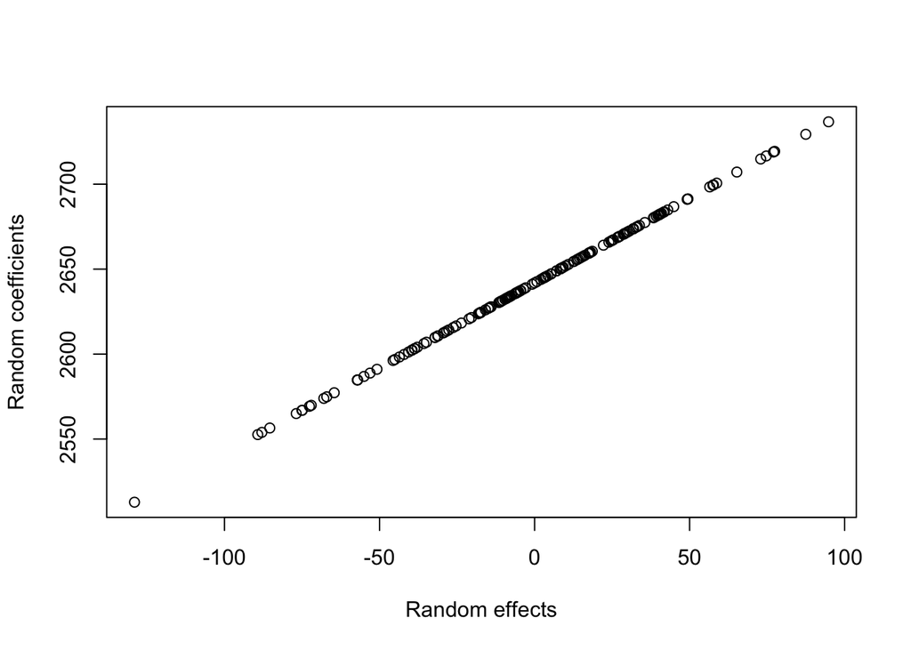

```r
plot(wl_re$value, wl_coef$value, xlab = "Random effects", ylab = "Random coefficients")
```

Now let’s produce similar data for the right wings and look at correlations between left and right wings Line random effects, and left and right wings Line random coefficients. Both correlations should be similar

Correlation between left and right wings random effects

```r
cor.test(wl_re$value, wr_re$value)
```

```
##
##  Pearson's product-moment correlation
##
## data:  wl_re$value and wr_re$value
## t = 228.34, df = 165, p-value < 2.2e-16
## alternative hypothesis: true correlation is not equal to 0
## 95 percent confidence interval:
##  0.9978568 0.9988375
## sample estimates:
##       cor
## 0.9984215
```

Correlation between left and right wings random coefficients

```r
cor.test(wl_coef$value, wr_coef$value)
```

```
##
##  Pearson's product-moment correlation
##
## data:  wl_coef$value and wr_coef$value
## t = 228.34, df = 165, p-value < 2.2e-16
## alternative hypothesis: true correlation is not equal to 0
## 95 percent confidence interval:
##  0.9978568 0.9988375
## sample estimates:
##       cor
## 0.9984215
```

Using random effects or random coefficients does not make any difference regarding trait correltions. Since we are not interested in knowing the Line estimates (we want to know how lines differ from each other, not their actual value) we can probably use the random effects for the remaining analyses.